# How Borrowers characteristics influence Rates Charged on their Loans

## Investigation Overview

In this analysis, I intend to look at how characteristics of Borrowers could be used to predict the appropriate rate to be charged them. I also wanted to know which category of borrowers have the highest default risk and compare it with the category which actually defaults the most.

## Dataset Overview

The dataset used for the analysis originally contains 113,937 rows with 81 columns (depicting different variables related to each loan processed). However for the sake of this analysis, only 21 relevent features were selected with 97752 data points maintained. The 16185 data points were deleted due to inconsistencies and missing information.

## Distribution of BorrowerAPR and BorrowerRate

Both Borrowers' APR and Borrowers' Rate tend to have a normal distribution and and densed between 0.1 and 0.2. However, the distribution of their modal values seems different. APR's mode is between 0.1 and 0.2 whereas Borrower's Rate mode is between 0.3 and 0.35

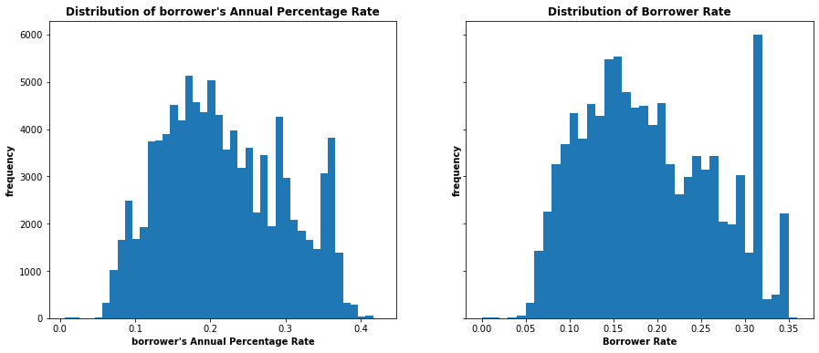

## BorrowerAPR vs Listing Category

The listing categories can be verified by clicking [here](https://docs.google.com/spreadsheets/d/1gDyi_L4UvIrLTEC6Wri5nbaMmkGmLQBk-Yx3z0XDEtI/edit#gid=0)

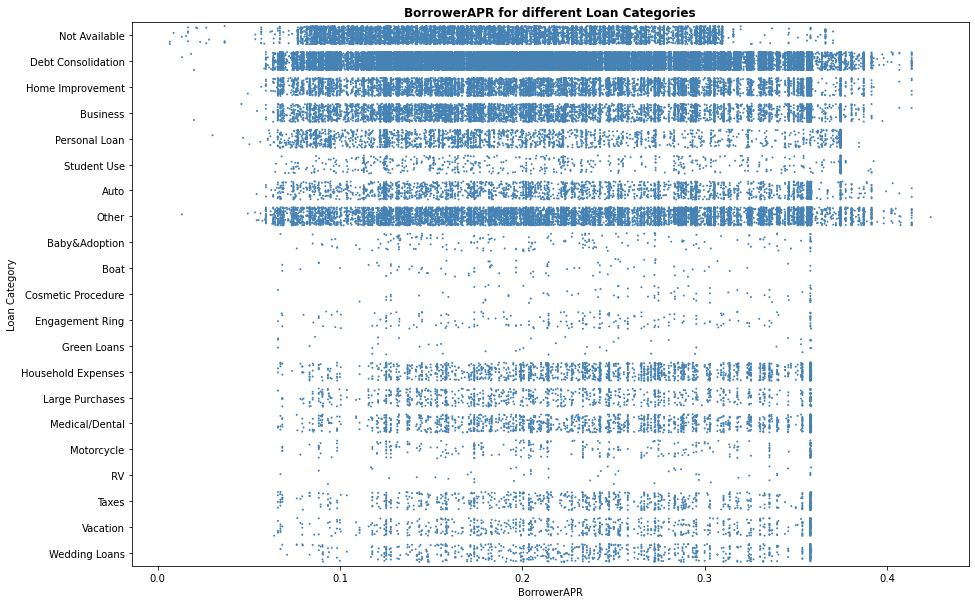

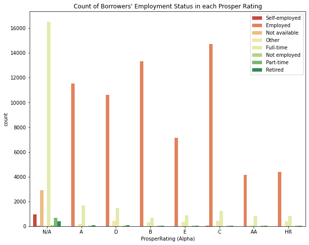

## LoanStatus vs BorrowerAPR in each EmploymentStatus

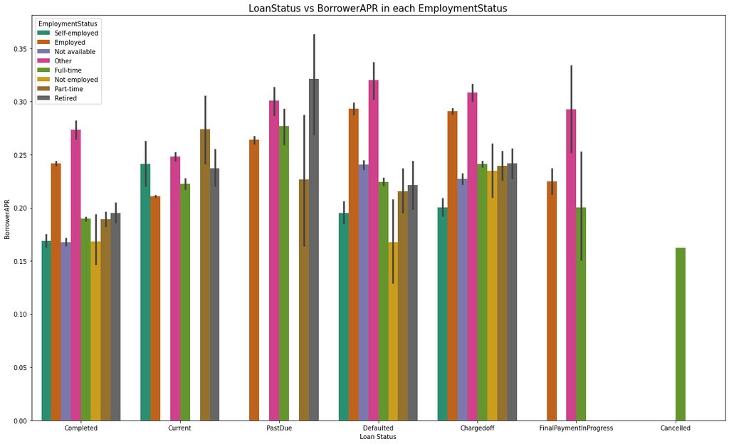

## Employment Status of Defaulters and their preferred Loan Terms vs BorrowerAPR charged on their Loans

- Interestingly, unemployed borrowers tend to pay the least BorrowerAPR even though they may seem to be associated with the highest risk.
- It is also clear that the unemployed tend to prefer loan for a term of 36months.
- It is obvious that only employed defaulters that take on loans for a 12 months term.

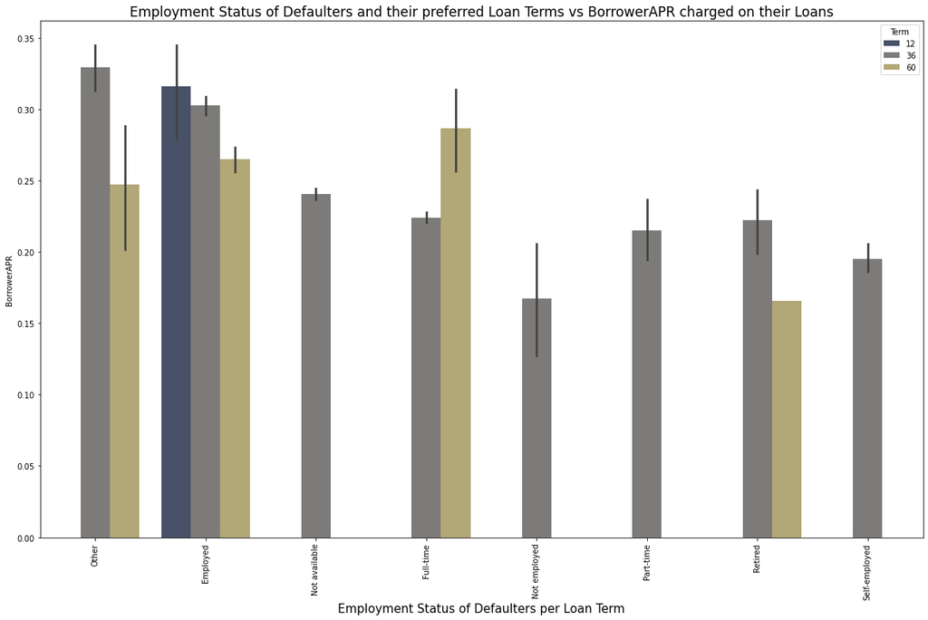

## ProsperRating (Alpha) of Defaulters per Employment Status

- From the of the full-time and not-available status defaulters took their loans before the implementation of the ProsperRating(ALpha), however, it is very obvious that most of the defaulters were coming from the employed group.
- Obviously, those rated D are the highest group of defaulters

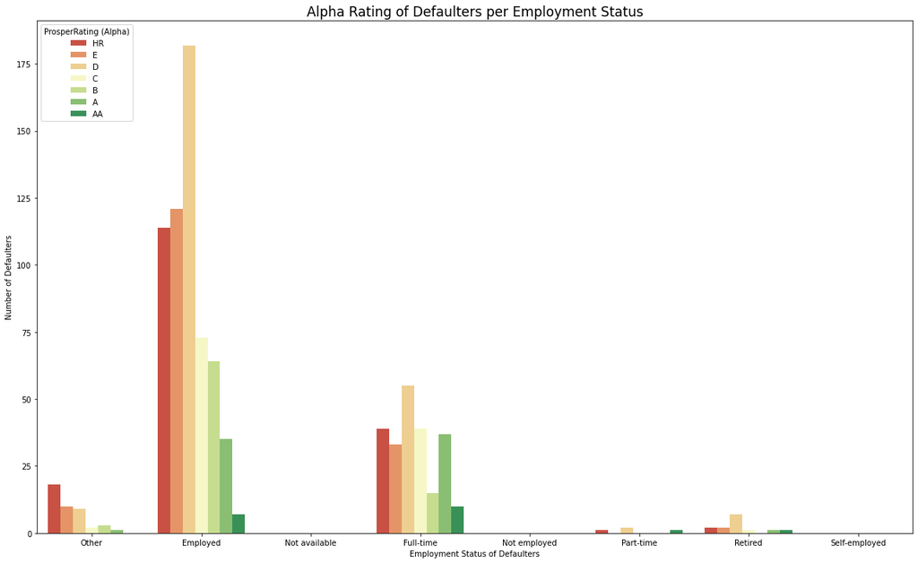